# Pertemuan 6_Contoh Kasus_Microcredential

[figure not shown]

## Daftar Isi:

##### Visualisasi Variabel:

1. Pie Chart
2. Bar Chart
3. Scatter Plot
4. Heatmap

##### Visualisasi Statistik:

1. Histogram
2. Correlation dan Causation
3. Variabel Kategori Statistik

##### Visualisasi Deskriptif Statistik

##### ANOVA: Analysis of Variance

**Catatan :** Jika belum pernah instal library, gunakan perintah berikut secara inline atau melalui terminal.

1. !pip install pandas
2. !pip install numpy
3. !pip install scipy
4. !pip install matplotlib
5. !pip install seaborn

# *Visualisasi Variabel*

```python
# import library
import pandas as pd
import numpy as np
import matplotlib.pyplot as plt
import seaborn as sns
```

## 1. Pie chart

**Pie chart** digunakan untuk menunjukkan seberapa banyak dari setiap jenis kategori dalam dataset berbanding dengan keseluruhan.

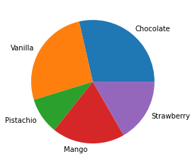

```python
# visualisasi pie chart
flavors = ('Chocolate', 'Vanilla', 'Pistachio', 'Mango', 'Strawberry')
votes = (12, 11, 4, 8, 7)
plt.pie(
    votes,
    labels=flavors,
)
plt.show()
```

Jika kita ingin melihat berapa persen kontribusi masing-masing rasa es kirim, kita bisa menggunakan argumen `autopct`.

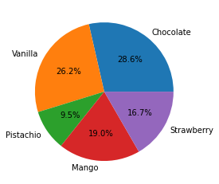

```python
# melihat persen kontribusi pada pie chart
flavors = ('Chocolate', 'Vanilla', 'Pistachio', 'Mango', 'Strawberry')
votes = (12, 11, 4, 8, 7)
plt.pie(
    votes,
    labels=flavors,
    autopct='%1.1f%%',
)
plt.show()
```

Kita dapat memberikan warna yang lebih banyak dengan 'kode warna html'.

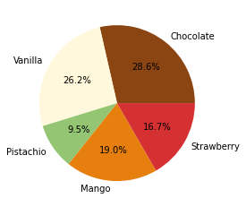

```python
# kostumisasi warna pie chart
flavors = ('Chocolate', 'Vanilla', 'Pistachio', 'Mango', 'Strawberry')
votes = (12, 11, 4, 8, 7)
colors = ('#8B4513', '#FFF8DC', '#93C572', '#E67F0D', '#D53032')
plt.pie(
    votes,
    labels=flavors,
    autopct='%1.1f%%',
    colors=colors,
)
plt.show()
```

Jika kita ingin melakukan highlight terhadap data mangga, kemudian mendorong data mangga keluar sebesar 0,1 sambil menjaga semua potongan lainnya tetap berada ditengah bisa menggunakan argumen `explode`.

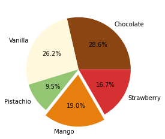

```python
# menambah highlight terhadap data
flavors = ('Chocolate', 'Vanilla', 'Pistachio', 'Mango', 'Strawberry')
votes = (12, 11, 4, 8, 7)
colors = ('#8B4513', '#FFF8DC', '#93C572', '#E67F0D', '#D53032')
explode = (0, 0, 0, 0.1, 0)
plt.pie(
    votes,
    labels=flavors,
    autopct='%1.1f%%',
    colors=colors,
    explode=explode,
)
plt.show()
```

Kita bisa memberinya sedikit tampilan tiga dimensi dengan menambahkan bayangan dengan argumen `shadow`.

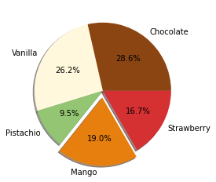

```python
# menambah bayangan visualisasi
flavors = ('Chocolate', 'Vanilla', 'Pistachio', 'Mango', 'Strawberry')
votes = (12, 11, 4, 8, 7)
colors = ('#8B4513', '#FFF8DC', '#93C572', '#E67F0D', '#D53032')
explode = (0, 0, 0, 0.1, 0)
plt.pie(
    votes,
    labels=flavors,
    autopct='%1.1f%%',
    colors=colors,
    explode=explode,
    shadow=True
    )
plt.show()
```

Untuk menambahkan judul menggunakan `plt.title().`

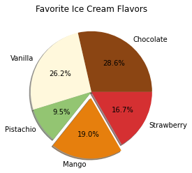

```python
# menambahkan judul
flavors = ('Chocolate', 'Vanilla', 'Pistachio', 'Mango', 'Strawberry')
votes = (12, 11, 4, 8, 7)
colors = ('#8B4513', '#FFF8DC', '#93C572', '#E67F0D', '#D53032')
explode = (0, 0, 0, 0.1, 0)

plt.title('Favorite Ice Cream Flavors')
plt.pie(
    votes,
    labels=flavors,
    autopct='%1.1f%%',
    colors=colors,
    explode=explode,
    shadow=True
    )
plt.show()
```

## 2. Bar Chart

**Bar Chart** adalah merupakan tools visualisassi yang dapat digunakan untuk membandingkan data kategorikal. Mirip dengan diagram lingkaran, diagram ini dapat digunakan untuk membandingkan kategori data dengan yang lain.

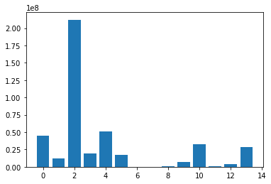

```python
# memuat data
countries = ('Argentina', 'Bolivia', 'Brazil', 'Chile', 'Colombia', 'Ecuador',
             'Falkland Islands', 'French Guiana', 'Guyana', 'Paraguay', 'Peru',
             'Suriname', 'Uruguay', 'Venezuela')

populations = (45076704, 11626410, 212162757, 19109629, 50819826, 17579085,
               3481, 287750, 785409, 7107305, 32880332, 585169, 3470475,
               28258770)

# visualisasi bar chart
x_coords = np.arange(len(countries))
plt.bar(x_coords, populations)
plt.show()
```

Karena kita memiliki nama label yang relatif lebar maka kita dapat memberikan argumen `tick_label` pada bar untuk memutar label sejauh 90 derajat agar lebih mudah dibaca.

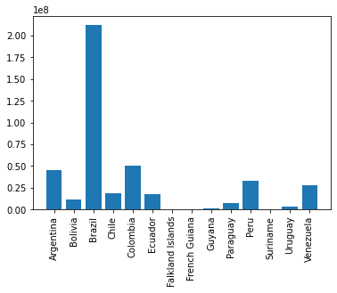

```python
# memutar label 90 derajat
countries = ('Argentina', 'Bolivia', 'Brazil', 'Chile', 'Colombia', 'Ecuador',
             'Falkland Islands', 'French Guiana', 'Guyana', 'Paraguay', 'Peru',
             'Suriname', 'Uruguay', 'Venezuela')

populations = (45076704, 11626410, 212162757, 19109629, 50819826, 17579085,
               3481, 287750, 785409, 7107305, 32880332, 585169, 3470475,
               28258770)

x_coords = np.arange(len(countries))
plt.bar(x_coords, populations, tick_label=countries)
plt.xticks(rotation=90) #memutar labels x-axis
plt.show()
```

Kita dapat menambahkan label ke diagram batang untuk membantu membuat diagram agar lebih mudah dibaca menggunakan `plt.ylabel()` dan `plt.xlabel()`.

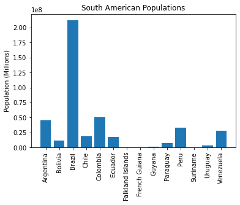

```python
# menambah label y
countries = ('Argentina', 'Bolivia', 'Brazil', 'Chile', 'Colombia', 'Ecuador',
             'Falkland Islands', 'French Guiana', 'Guyana', 'Paraguay', 'Peru',
             'Suriname', 'Uruguay', 'Venezuela')

populations = (45076704, 11626410, 212162757, 19109629, 50819826, 17579085,
              3481, 287750, 785409, 7107305, 32880332, 585169, 3470475,
              28258770)

x_coords = np.arange(len(countries))
plt.bar(x_coords, populations, tick_label=countries)
plt.xticks(rotation=90)
plt.ylabel('Population (Millions)')
plt.title('South American Populations')
plt.show()
```

Jika ingin mengetahui Apa negara terpadat kedua di Amerika Selatan? mungkin harus sedikit menatap Argentina dan Kolombia. Ini karena data diurutkan menurut abjad, yang bukan merupakan pengurutan yang paling berguna untuk menjawab pertanyaan tentang data. Sayangnya Matplotlib tidak memiliki penyortiran bawaan. Sebagai gantinya, kita dapat mengimpor Pandas dan menggunakan `.sort_values()` untuk mengurutkan data.

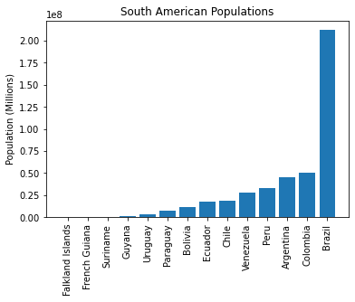

```python
# mengurutkan data
countries = ('Argentina', 'Bolivia', 'Brazil', 'Chile', 'Colombia', 'Ecuador',
             'Falkland Islands', 'French Guiana', 'Guyana', 'Paraguay', 'Peru',
             'Suriname', 'Uruguay', 'Venezuela')

populations = (45076704, 11626410, 212162757, 19109629, 50819826, 17579085,
               3481, 287750, 785409, 7107305, 32880332, 585169, 3470475,
               28258770)

df = pd.DataFrame({
    'Country': countries,
    'Population': populations,
})
df.sort_values(by='Population', inplace=True)

x_coords = np.arange(len(df))
plt.bar(x_coords, df['Population'], tick_label=df['Country'])
plt.xticks(rotation=90)
plt.ylabel('Population (Millions)')
plt.title('South American Populations')
plt.show()
```

Kita dapat melihat bahwa Kolombia adalah negara terbesar kedua . Jika kita ingin melakukan highlight pada Kolombia, kita dapat menggunakan argumen `color[-2] = 'FF0000'`.

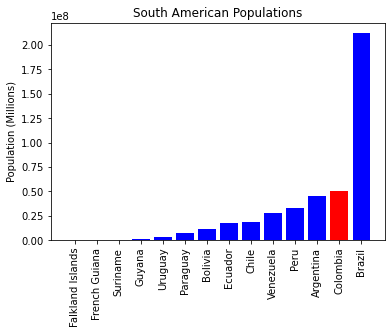

```python
import matplotlib.pyplot as plt
import numpy as np
import pandas as pd

countries = ('Argentina', 'Bolivia', 'Brazil', 'Chile', 'Colombia', 'Ecuador',
             'Falkland Islands', 'French Guiana', 'Guyana', 'Paraguay', 'Peru',
             'Suriname', 'Uruguay', 'Venezuela')

populations = (45076704, 11626410, 212162757, 19109629, 50819826, 17579085,
               3481, 287750, 785409, 7107305, 32880332, 585169, 3470475,
               28258770)

df = pd.DataFrame({
    'Country': countries,
    'Population': populations,
})
df.sort_values(by='Population', inplace=True)

x_coords = np.arange(len(df))
colors = ['#0000FF' for _ in range(len(df))]
colors[-2] = '#FF0000'
plt.bar(x_coords, df['Population'], tick_label=df['Country'], color=colors)
plt.xticks(rotation=90)
plt.ylabel('Population (Millions)')
plt.title('South American Populations')
plt.show()
```

Kita juga bisa membuat grafik menjadi lebih besar menggunakan metode `figure()`. Kita dapat meneruskan dengan argumen `figsize =` yang mewakili lebar dan tinggi gambar dalam inch.

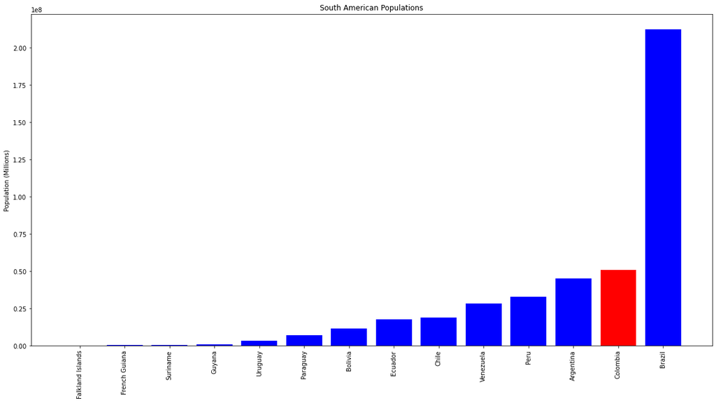

```python
# mengatur ukuran gambar
countries = ('Argentina', 'Bolivia', 'Brazil', 'Chile', 'Colombia', 'Ecuador',
             'Falkland Islands', 'French Guiana', 'Guyana', 'Paraguay', 'Peru',
             'Suriname', 'Uruguay', 'Venezuela')

populations = (45076704, 11626410, 212162757, 19109629, 50819826, 17579085,
               3481, 287750, 785409, 7107305, 32880332, 585169, 3470475,
               28258770)

df = pd.DataFrame({
    'Country': countries,
    'Population': populations,
})
df.sort_values(by='Population', inplace=True)

x_coords = np.arange(len(df))
colors = ['#0000FF' for _ in range(len(df))]
colors[-2] = '#FF0000'
plt.figure(figsize=(20,10))
plt.bar(x_coords, df['Population'], tick_label=df['Country'], color=colors)
plt.xticks(rotation=90)
plt.ylabel('Population (Millions)')
plt.title('South American Populations')
plt.show()
```

## 3. Line Graphs

**Line Graph** adalah bentuk visualisasi lainya selain diagram lingkaran dan diagram batang. Meskipun diagram lingkaran dan diagram batang berguna untuk menunjukkan bagaimana kelas data saling terkait, Line Graph lebih berguna untuk menunjukkan bagaimana kemajuan data selama beberapa periode.

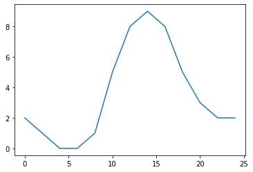

```python
# memuat data
temperature_c = [2, 1, 0, 0, 1, 5, 8, 9, 8, 5, 3, 2, 2]
hour = [0, 2, 4, 6, 8, 10, 12, 14, 16, 18, 20, 22, 24]

# visualisasi line graph
plt.plot(
  hour,
  temperature_c
)
plt.show()
```

Kita juga bisa menambahkan elemen bagan standar dari `title()`, `ylabel()`, dan `xlabel()`.

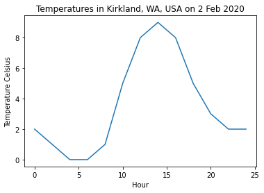

```python
# menambah title(), ylabel(), dan xlabel()
temperature_c = [2, 1, 0, 0, 1, 5, 8, 9, 8, 5, 3, 2, 2]
hour = [0, 2, 4, 6, 8, 10, 12, 14, 16, 18, 20, 22, 24]

plt.plot(
  hour,
  temperature_c,
)
plt.title('Temperatures in Kirkland, WA, USA on 2 Feb 2020')
plt.ylabel('Temperature Celsius')
plt.xlabel('Hour')
plt.show()
```

Kita juga dapat menambahkan penanda **"x"** di setiap titik data (Gambar Pada contoh di bawah ini kita menambahkan penanda **x** \pada setiap titik data menggunakan argumen `marker = 'x'`.

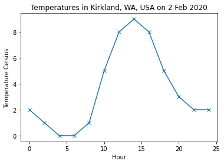

```python
# menambahkan penanda titik
temperature_c = [2, 1, 0, 0, 1, 5, 8, 9, 8, 5, 3, 2, 2]
hour = [0, 2, 4, 6, 8, 10, 12, 14, 16, 18, 20, 22, 24]

plt.plot(
  hour,
  temperature_c,
  marker='x',
)
plt.title('Temperatures in Kirkland, WA, USA on 2 Feb 2020')
plt.ylabel('Temperature Celsius')
plt.xlabel('Hour')
plt.show()
```

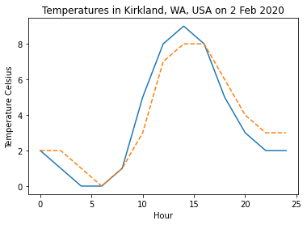

```python
# visualisasi line graph dengan 2 nilai
temperature_c_actual = [2, 1, 0, 0, 1, 5, 8, 9, 8, 5, 3, 2, 2]
temperature_c_predicted = [2, 2, 1, 0, 1, 3, 7, 8, 8, 6, 4, 3, 3]
hour = [0, 2, 4, 6, 8, 10, 12, 14, 16, 18, 20, 22, 24]

plt.plot(hour, temperature_c_actual)
plt.plot(hour, temperature_c_predicted, linestyle='--')
plt.title('Temperatures in Kirkland, WA, USA on 2 Feb 2020')
plt.ylabel('Temperature Celsius')
plt.xlabel('Hour')
plt.show()
```

## 4. Scatter Plot

**Scatter plot** berfungsi baik untuk data dengan dua komponen numerik. Scatter plot dapat memberikan informasi yang berguna terutama mengenai pola atau pencilan.

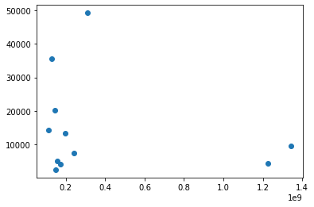

```python
# visualisasi scatter plot
country = ['Bangladesh', 'Brazil', 'China', 'India', 'Indonesia', 'Japan',
           'Mexico', 'Nigeria', 'Pakistan', 'Russia', 'United States']
gdp = [2421, 13418, 9475, 4353, 7378, 35477, 14276, 5087, 4133, 20255, 49267]
population = [148692131, 194946470, 1341335152, 1224614327, 239870937,
              126535920, 113423047, 158423182, 173593383, 142958164, 310383948]

plt.scatter(population, gdp)
plt.show()
```

Contoh di bawah ini, kita memplot diameter dan berat sekumpulan lemon dan jeruk nipis agar dapat melihat apakah kita dapat menentukan polanya.

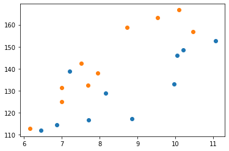

```python
# visualisasi scatterplot dengan 2 variabel
lemon_diameter = [6.44, 6.87, 7.7, 8.85, 8.15, 9.96, 7.21, 10.04, 10.2, 11.06]
lemon_weight = [112.05, 114.58, 116.71, 117.4, 128.93,
                132.93, 138.92, 145.98, 148.44, 152.81]

lime_diameter = [6.15, 7.0, 7.0, 7.69, 7.95, 7.51, 10.46, 8.72, 9.53, 10.09]
lime_weight = [112.76, 125.16, 131.36, 132.41, 138.08,
               142.55, 156.86, 158.67, 163.28, 166.74]

plt.scatter(lemon_diameter, lemon_weight)
plt.scatter(lime_diameter, lime_weight)
plt.show()
```

Melihat data sampel di atas, tidak ada pola yang sangat jelas. Namun, salah satu jenis jeruk tampaknya lebih berat dan diameternya lebih besar. Tapi yang mana? Mari perjelas bagian ini sedikit. Pertama kita akan menambahkan judul menggunakan `plt.title()`, x-label menggunakan `plt.xlabel()`, dan y-label menggunakan `plt.ylabel()` .

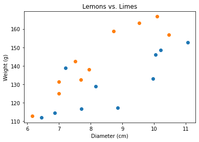

```python
# menambahkan title, xlabel, dan ylabel
lemon_diameter = [6.44, 6.87, 7.7, 8.85, 8.15, 9.96, 7.21, 10.04, 10.2, 11.06]
lemon_weight = [112.05, 114.58, 116.71, 117.4, 128.93,
                132.93, 138.92, 145.98, 148.44, 152.81]

lime_diameter = [6.15, 7.0, 7.0, 7.69, 7.95, 7.51, 10.46, 8.72, 9.53, 10.09]
lime_weight = [112.76, 125.16, 131.36, 132.41, 138.08,
               142.55, 156.86, 158.67, 163.28, 166.74]

plt.title('Lemons vs. Limes')
plt.xlabel('Diameter (cm)')
plt.ylabel('Weight (g)')
plt.scatter(lemon_diameter, lemon_weight)
plt.scatter(lime_diameter, lime_weight)
plt.show()
```

Kita dapat menambahkan beberapa warna dan legenda untuk membuat scatter plot sedikit lebih intuitif. Kita menambahkan warna dengan meneruskan color = argumen ke `plt.scatter()`. Dalam hal ini kita hanya mengatur titik lemon menjadi kuning menggunakan `color = 'y'` dan titik lime menjadi hijau menggunakan `color = 'g'`.

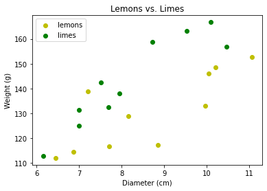

```python
# kostumisasi warna scatter plot
lemon_diameter = [6.44, 6.87, 7.7, 8.85, 8.15, 9.96, 7.21, 10.04, 10.2, 11.06]
lemon_weight = [112.05, 114.58, 116.71, 117.4, 128.93,
                132.93, 138.92, 145.98, 148.44, 152.81]

lime_diameter = [6.15, 7.0, 7.0, 7.69, 7.95, 7.51, 10.46, 8.72, 9.53, 10.09]
lime_weight = [112.76, 125.16, 131.36, 132.41, 138.08,
               142.55, 156.86, 158.67, 163.28, 166.74]

plt.title('Lemons vs. Limes')
plt.xlabel('Diameter (cm)')
plt.ylabel('Weight (g)')
plt.scatter(lemon_diameter, lemon_weight, color='y')
plt.scatter(lime_diameter, lime_weight, color='g')
plt.legend(['lemons', 'limes'])
plt.show()
```

## 5. Heatmap

**Heatmap** adalah jenis visualisasi yang menggunakan kode warna untuk mewakili nilai / kepadatan relatif data di seluruh permukaan. Seringkali Heatmap adalah bagan tabel, tetapi tidak harus terbatas pada itu. Untuk data tabular, terdapat label pada sumbu x dan y. Nilai di persimpangan label tersebut dipetakan ke warna.

Langkah-langkah untuk melakukan visualisasi heatmap adalah sebagai berikut

1. Pada kode di bawah ini, pertama kita mengimpor seaborn.
2. Kita kemudian membuat daftar yang berisi nama 12 kota terbesar di dunia dan 12 bulan dalam setahun.
3. Selanjutnya kita menetapkan daftar-daftar ke variabel suhu. Setiap baris dalam daftar mewakili sebuah kota.
4. Setiap kolom adalah satu bulan. Nilai-nilai tersebut adalah suhu tinggi rata-rata untuk kota selama bulan tersebut.
5. Pada tahap akhir kita memanggil `sns.heatmap()` untuk membuat peta panas. Kita mengirimkan data suhu, nama kota sebagai label-y, dan singkatan bulan sebagai label-x.

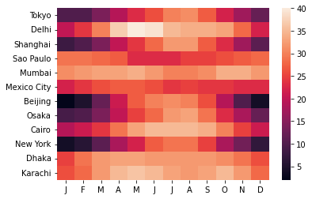

```python
# visualisasi heatmap
import seaborn as sns
cities = ['Tokyo', 'Delhi', 'Shanghai', 'Sao Paulo', 'Mumbai', 'Mexico City',
          'Beijing', 'Osaka', 'Cairo', 'New York', 'Dhaka', 'Karachi']
months = ['J', 'F', 'M', 'A', 'M', 'J', 'J', 'A', 'S', 'O', 'N', 'D']
temperatures = [
  [10, 10, 14, 19, 23, 26, 30, 31, 27, 22, 17, 12], # Tokyo
  [20, 24, 30, 37, 40, 39, 35, 34, 34, 33, 28, 22], # Delhi
  [ 8, 10, 14, 20, 24, 28, 32, 32, 27, 23, 17, 11], # Shanghai
  [29, 29, 28, 27, 23, 23, 23, 25, 25, 26, 27, 28], # Sao Paulo
  [31, 32, 33, 33, 34, 32, 30, 30, 31, 34, 34, 32], # Mumbai
  [22, 24, 26, 27, 27, 26, 24, 25, 24, 24, 23, 23], # Mexico City
  [ 2,  5, 12, 21, 27, 30, 31, 30, 26, 19, 10,  4], # Beijing
  [ 9, 10, 14, 20, 25, 28, 32, 33, 29, 23, 18, 12], # Osaka
  [19, 21, 24, 29, 33, 35, 35, 35, 34, 30, 25, 21], # Cairo
  [ 4,  6, 11, 18, 22, 27, 29, 29, 25, 18, 13,  7], # New York
  [25, 29, 32, 33, 33, 32, 32, 32, 32, 31, 29, 26], # Dhaka
  [26, 28, 32, 35, 36, 35, 33, 32, 33, 35, 32, 28], # Karachi
]
sns.heatmap(temperatures, yticklabels=cities, xticklabels=months)
```

Bagian kiri dan kanan grafik mungkin berisi warna yang lebih gelap, yang memetakan ke suhu yang lebih dingin, tetapi itu pun sulit untuk ditentukan. Kita perlu mengurutkan secara manual kota-kota tersebut, dari yang terkecil ke yang terbesar. Mari kita coba ubah pengurutan berdasarkan lintang pada garis bumi

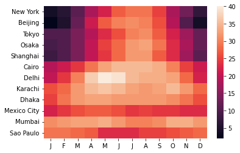

```python
# mengurutkan berdasarkan lintang pada garis bumi
cities = ['New York', 'Beijing', 'Tokyo', 'Osaka', 'Shanghai', 'Cairo', 'Delhi',
          'Karachi', 'Dhaka', 'Mexico City', 'Mumbai', 'Sao Paulo']

temperatures = [
  [ 4,  6, 11, 18, 22, 27, 29, 29, 25, 18, 13,  7], # New York
  [ 2,  5, 12, 21, 27, 30, 31, 30, 26, 19, 10,  4], # Beijing
  [10, 10, 14, 19, 23, 26, 30, 31, 27, 22, 17, 12], # Tokyo
  [ 9, 10, 14, 20, 25, 28, 32, 33, 29, 23, 18, 12], # Osaka
  [ 8, 10, 14, 20, 24, 28, 32, 32, 27, 23, 17, 11], # Shanghai
  [19, 21, 24, 29, 33, 35, 35, 35, 34, 30, 25, 21], # Cairo
  [20, 24, 30, 37, 40, 39, 35, 34, 34, 33, 28, 22], # Delhi
  [26, 28, 32, 35, 36, 35, 33, 32, 33, 35, 32, 28], # Karachi
  [25, 29, 32, 33, 33, 32, 32, 32, 32, 31, 29, 26], # Dhaka
  [22, 24, 26, 27, 27, 26, 24, 25, 24, 24, 23, 23], # Mexico City
  [31, 32, 33, 33, 34, 32, 30, 30, 31, 34, 34, 32], # Mumbai
  [29, 29, 28, 27, 23, 23, 23, 25, 25, 26, 27, 28], # Sao Paulo
]

sns.heatmap(temperatures, yticklabels=cities, xticklabels=months)
#<matplotlib.axes._subplots.AxesSubplot at 0x22345cc0a48>
```

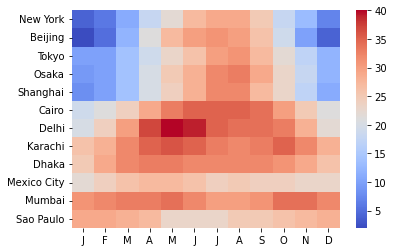

```python
# mengubah skema warna dengan cmap
cities = ['New York', 'Beijing', 'Tokyo', 'Osaka', 'Shanghai', 'Cairo', 'Delhi',
          'Karachi', 'Dhaka', 'Mexico City', 'Mumbai', 'Sao Paulo']

temperatures = [
  [ 4,  6, 11, 18, 22, 27, 29, 29, 25, 18, 13,  7], # New York
  [ 2,  5, 12, 21, 27, 30, 31, 30, 26, 19, 10,  4], # Beijing
  [10, 10, 14, 19, 23, 26, 30, 31, 27, 22, 17, 12], # Tokyo
  [ 9, 10, 14, 20, 25, 28, 32, 33, 29, 23, 18, 12], # Osaka
  [ 8, 10, 14, 20, 24, 28, 32, 32, 27, 23, 17, 11], # Shanghai
  [19, 21, 24, 29, 33, 35, 35, 35, 34, 30, 25, 21], # Cairo
  [20, 24, 30, 37, 40, 39, 35, 34, 34, 33, 28, 22], # Delhi
  [26, 28, 32, 35, 36, 35, 33, 32, 33, 35, 32, 28], # Karachi
  [25, 29, 32, 33, 33, 32, 32, 32, 32, 31, 29, 26], # Dhaka
  [22, 24, 26, 27, 27, 26, 24, 25, 24, 24, 23, 23], # Mexico City
  [31, 32, 33, 33, 34, 32, 30, 30, 31, 34, 34, 32], # Mumbai
  [29, 29, 28, 27, 23, 23, 23, 25, 25, 26, 27, 28], # Sao Paulo
]

sns.heatmap(
    temperatures,
    yticklabels=cities,
    xticklabels=months,
    cmap='coolwarm',
)
```

# 1. Histogram

**Histogram** adalah salah satu visualisasi yang cukup penting dalam memahami distribusi pada data kita. Pandas Histogram menyediakan method yang memudahkan kita untuk membuat histogram. Plot histogram secara tradisional hanya membutuhkan satu dimensi data. Ini dimaksudkan untuk menunjukkan jumlah nilai atau kumpulan nilai secara serial.

Sebagai contoh studi kasus data yang akan digunakan adalah *automobile.csv* yang merupakan data-data spesifikasi kendaraan dari berbagai merek dan harganya.

```python
# memuat data
path='https://s3-api.us-geo.objectstorage.softlayer.net/cf-courses-data/CognitiveClass/DA0101EN/automobileEDA.csv'
df = pd.read_csv(path)
df.head()
```

|  | symboling | normalized-losses | make | aspiration | num-of-doors | body-style | drive-wheels | engine-location | wheel-base | length | ... | compression-ratio | horsepower | peak-rpm | city-mpg | highway-mpg | price | city-L/100km | horsepower-binned | diesel | gas |
| --- | --- | --- | --- | --- | --- | --- | --- | --- | --- | --- | --- | --- | --- | --- | --- | --- | --- | --- | --- | --- | --- |
| 0 | 3 | 122 | alfa-romero | std | two | convertible | rwd | front | 88.6 | 0.811148 | ... | 9.0 | 111.0 | 5000.0 | 21 | 27 | 13495.0 | 11.190476 | Medium | 0 | 1 |
| 1 | 3 | 122 | alfa-romero | std | two | convertible | rwd | front | 88.6 | 0.811148 | ... | 9.0 | 111.0 | 5000.0 | 21 | 27 | 16500.0 | 11.190476 | Medium | 0 | 1 |
| 2 | 1 | 122 | alfa-romero | std | two | hatchback | rwd | front | 94.5 | 0.822681 | ... | 9.0 | 154.0 | 5000.0 | 19 | 26 | 16500.0 | 12.368421 | Medium | 0 | 1 |
| 3 | 2 | 164 | audi | std | four | sedan | fwd | front | 99.8 | 0.848630 | ... | 10.0 | 102.0 | 5500.0 | 24 | 30 | 13950.0 | 9.791667 | Medium | 0 | 1 |
| 4 | 2 | 164 | audi | std | four | sedan | 4wd | front | 99.4 | 0.848630 | ... | 8.0 | 115.0 | 5500.0 | 18 | 22 | 17450.0 | 13.055556 | Medium | 0 | 1 |

5 rows × 29 columns

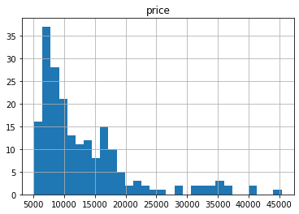

```python
df.hist(column='price', bins=30);
```

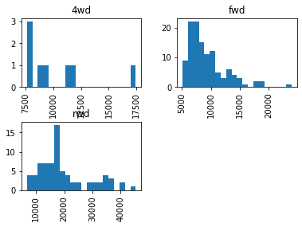

```python
# melakukan plot beberapa grup
df.hist(column='price', by='drive-wheels', bins=20);
```

Untuk memplot beberapa seri, kita bisa menggunakan metode `df.plot(kind='hist)`.

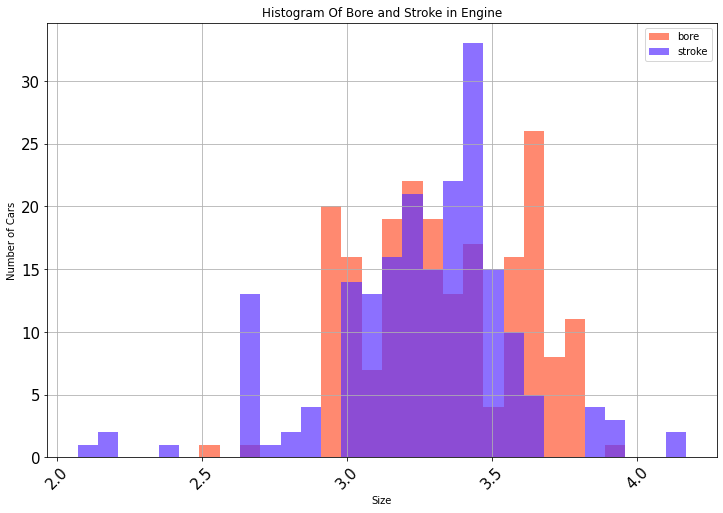

```python
# melakukan plot pada beberapa seri
df[['bore','stroke']].plot(kind='hist',
        alpha=0.7,
        bins=30,
        title='Histogram Of Bore and Stroke in Engine',
        rot=45,
        grid=True,
        figsize=(12,8),
        fontsize=15,
        color=['#FF5733', '#5C33FF'])
plt.xlabel('Size')
plt.ylabel("Number of Cars");
```

## 2. Correlation dan Causation

**Korelasi** merupakan suatu pengukuran sejauh mana nilai saling ketergantungan antar variabel. Causation merupakan hubungan antara sebab dan akibat antara dua variable Penting untuk mengetahui perbedaan antara keduanya dan bahwa korelasi tidak mendeskripsikan sebab-akibat. Menentukan korelasi jauh lebih sederhana menentukan sebab memerlukan analisis lebih lanjut.

### Korelasi Pearson

Korelasi Pearson mengukur ketergantungan linier antara dua variabel X dan Y. Koefisien yang dihasilkan adalah nilai antara -1 dan 1 inklusif, di mana: • 1: Total korelasi linier positif. • 0 : Tidak ada korelasi linier, kedua variabel kemungkinan besar tidak saling mempengaruhi. • -1: Total korelasi linier negatif. Pearson Correlation adalah metode default dari fungsi `"corr"`. Seperti sebelumnya kita dapat menghitung Korelasi Pearson dari variabel 'int64' atau 'float64'. Terkadang kita ingin mengetahui signifikansi dari estimasi korelasi, kita dapat menggunakan p-value. P-Value: Berapa nilai P ini? Nilai P adalah nilai probabilitas bahwa korelasi antara kedua variabel ini signifikan secara statistik. Biasanya, kita memilih tingkat signifikansi 0,05, yang berarti bahwa kami yakin bahwa 95% korelasi antar variabel signifikan. Dengan konvensi, ketika • nilai p adalah $<$ 0,001: kami katakan ada bukti kuat bahwa korelasinya signifikan. • nilai p adalah $<$ 0,05: terdapat bukti moderat bahwa korelasi tersebut signifikan. • nilai p adalah $<$ 0,1: ada bukti lemah bahwa korelasinya signifikan. • nilai p adalah $>$ 0,1: tidak ada bukti bahwa korelasi tersebut signifikan. Kita dapat menggunakan library scipy untuk menghitung korelasi dan p-value

```python
# import library scipy
from scipy import stats
```

```python
# menghitung koefisien korelasi pearson dari 'wheels-base' & 'price'
pearson_coef, p_value = stats.pearsonr(df['wheel-base'], df['price'])
print("The Pearson Correlation Coefficient is", pearson_coef, " with a P-value of P =", p_value)
```

```
The Pearson Correlation Coefficient is 0.5846418222655083  with a P-value of P = 8.076488270732873e-20
```

```python
# menghitung koefisien korelasi pearson dari 'horsepower' & 'price'
pearson_coef, p_value = stats.pearsonr(df['horsepower'], df['price'])
print("The Pearson Correlation Coefficient is", pearson_coef, " with a P-value of P = ", p_value)
```

```
The Pearson Correlation Coefficient is 0.8095745670036555  with a P-value of P =  6.369057428261186e-48
```

```python
# daftar tipe data setiap kolom
print(df.dtypes)
```

```
symboling              int64
normalized-losses      int64
make                  object
aspiration            object
num-of-doors          object
body-style            object
drive-wheels          object
engine-location       object
wheel-base           float64
length               float64
width                float64
height               float64
curb-weight            int64
engine-type           object
num-of-cylinders      object
engine-size            int64
fuel-system           object
bore                 float64
stroke               float64
compression-ratio    float64
horsepower           float64
peak-rpm             float64
city-mpg               int64
highway-mpg            int64
price                float64
city-L/100km         float64
horsepower-binned     object
diesel                 int64
gas                    int64
dtype: object
```

Misalnya, kita dapat menghitung korelasi antara variabel bertipe "int64" atau "float64" menggunakan method `"corr"`.

Untuk mulai memahami keterhubungan (linier) antara variabel individu dan harga. Kita dapat melakukan ini dengan menggunakan `"regplot"`. Fungsi ini yang memplot scatterplot ditambah garis regresi yang sesuai untuk data. Hubungan korelasi positf kuat antara variabel

```
(0.0, 53288.111512170835)
```

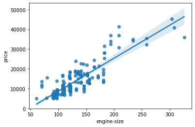

```python
# visualisasi scatter plot menggunakan regplot untuk mengetahui hubungan korelasi variabel 'engine-size' & 'price'
sns.regplot(x="engine-size", y="price", data=df)
plt.ylim(0,)
```

Saat kapasitas mesin naik, harga mobil tersebut juga tinggi: ini menunjukkan hubungan linier antara kedua variabel tersebut. Ukuran mesin berpotensi menjadi prediktor harga. Kita dapat memeriksa korelasi antara engine-size dan harga sekitar 0,87

```python
# mengetahui korelasi 'engine-size' & 'price'
df[["engine-size", "price"]].corr()
```

|  | engine-size | price |
| --- | --- | --- |
| engine-size | 1.000000 | 0.872335 |
| price | 0.872335 | 1.000000 |

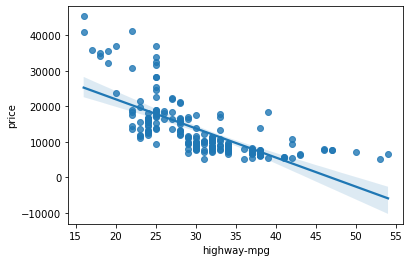

```python
# visualisasi scatter plot menggunakan regplot untuk mengetahui hubungan korelasi variabel 'engine-size' & 'price'
sns.regplot(x="highway-mpg", y="price", data=df)
```

Saat highway-mpg naik, harganya mobil tersebut rendah: ini menunjukkan hubungan terbalik/negatif antara kedua variabel ini. Highway mpg berpotensi menjadi prediktor harga. Hal ini bisa dilhat sebagai korelasi kuat negative . Kita dapat memeriksa korelasi antara 'highway-mpg' dan 'price' adalah -0,704

```python
# mengetahui korelasi 'highway-mpg' & 'price'
df[['highway-mpg', 'price']].corr()
```

|  | highway-mpg | price |
| --- | --- | --- |
| highway-mpg | 1.000000 | -0.704692 |
| price | -0.704692 | 1.000000 |

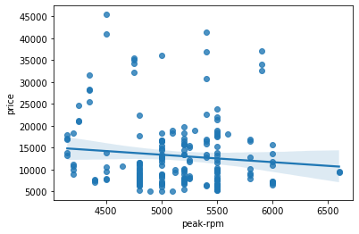

```python
# visualisasi scatter plot menggunakan regplot untuk mengetahui hubungan korelasi variabel 'peak-rpm' & 'price'
sns.regplot(x="peak-rpm", y="price", data=df)
```

Peak rpm sepertinya bukan merupakan prediktor harga yang baik karena garis regresinya mendekati horizontal . Titik-titik data sangat tersebar dan jauh dari garis pas, menunjukkan banyak variabilitas. Oleh karena itu itu bukan variabel yang dapat diandalkan untuk memperdiksi harga. Kita dapat memeriksa korelasi antara 'puncak-rpm' dan 'harga' dan melihatnya kira-kira -0,101616

```python
df[['peak-rpm','price']].corr()
```

|  | peak-rpm | price |
| --- | --- | --- |
| peak-rpm | 1.000000 | -0.101616 |
| price | -0.101616 | 1.000000 |

## 3. Variabel Kategori Statistik

Variabel kategori statistic adalah variabel yang menggambarkan 'karakteristik' dari unit data, dan dipilih dari sekelompok kategori. Variabel kategori dapat memiliki tipe "objek" atau "int64". Cara yang baik untuk memvisualisasikan variabel kategori adalah dengan menggunakan boxplot.

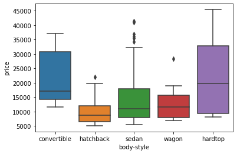

```python
# visualisasi variabel kategori statistik variabel 'body-style' & 'price'
sns.boxplot(x="body-style", y="price", data=df)
```

Kita melihat bahwa distribusi harga antara kategori kendaraan memiliki tumpang tindih yang signifikan, sehingga kategori tidak akan menjadi prediktor harga yang baik . Mari kita periksa variable lokasi mesin dan harga:

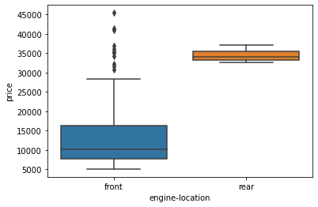

```python
# visualisasi variabel kategori statistik variabel 'engine-location' & 'price'
sns.boxplot(x="engine-location", y="price", data=df)
```

## Visualisasi Deskriptif Statistik

Fungsi deskripsikan secara otomatis menghitung statistik dasar untuk semua variabel kontinu . Analisis yang bisa kita dapatkan dari deskriptif statistik adalah • Jumlah variabel • Rata-rata • Standard deviasi • Nilai minimal • IQR (Interquartile Range: 25%, 50% and 75%) • Nilai Maximal

```python
# melakukan describe data
df.describe()
```

|  | symboling | normalized-losses | wheel-base | length | width | height | curb-weight | engine-size | bore | stroke | compression-ratio | horsepower | peak-rpm | city-mpg | highway-mpg | price | city-L/100km | diesel | gas |
| --- | --- | --- | --- | --- | --- | --- | --- | --- | --- | --- | --- | --- | --- | --- | --- | --- | --- | --- | --- |
| count | 201.000000 | 201.00000 | 201.000000 | 201.000000 | 201.000000 | 201.000000 | 201.000000 | 201.000000 | 201.000000 | 197.000000 | 201.000000 | 201.000000 | 201.000000 | 201.000000 | 201.000000 | 201.000000 | 201.000000 | 201.000000 | 201.000000 |
| mean | 0.840796 | 122.00000 | 98.797015 | 0.837102 | 0.915126 | 53.766667 | 2555.666667 | 126.875622 | 3.330692 | 3.256904 | 10.164279 | 103.405534 | 5117.665368 | 25.179104 | 30.686567 | 13207.129353 | 9.944145 | 0.099502 | 0.900498 |
| std | 1.254802 | 31.99625 | 6.066366 | 0.059213 | 0.029187 | 2.447822 | 517.296727 | 41.546834 | 0.268072 | 0.319256 | 4.004965 | 37.365700 | 478.113805 | 6.423220 | 6.815150 | 7947.066342 | 2.534599 | 0.300083 | 0.300083 |
| min | -2.000000 | 65.00000 | 86.600000 | 0.678039 | 0.837500 | 47.800000 | 1488.000000 | 61.000000 | 2.540000 | 2.070000 | 7.000000 | 48.000000 | 4150.000000 | 13.000000 | 16.000000 | 5118.000000 | 4.795918 | 0.000000 | 0.000000 |
| 25% | 0.000000 | 101.00000 | 94.500000 | 0.801538 | 0.890278 | 52.000000 | 2169.000000 | 98.000000 | 3.150000 | 3.110000 | 8.600000 | 70.000000 | 4800.000000 | 19.000000 | 25.000000 | 7775.000000 | 7.833333 | 0.000000 | 1.000000 |
| 50% | 1.000000 | 122.00000 | 97.000000 | 0.832292 | 0.909722 | 54.100000 | 2414.000000 | 120.000000 | 3.310000 | 3.290000 | 9.000000 | 95.000000 | 5125.369458 | 24.000000 | 30.000000 | 10295.000000 | 9.791667 | 0.000000 | 1.000000 |
| 75% | 2.000000 | 137.00000 | 102.400000 | 0.881788 | 0.925000 | 55.500000 | 2926.000000 | 141.000000 | 3.580000 | 3.410000 | 9.400000 | 116.000000 | 5500.000000 | 30.000000 | 34.000000 | 16500.000000 | 12.368421 | 0.000000 | 1.000000 |
| max | 3.000000 | 256.00000 | 120.900000 | 1.000000 | 1.000000 | 59.800000 | 4066.000000 | 326.000000 | 3.940000 | 4.170000 | 23.000000 | 262.000000 | 6600.000000 | 49.000000 | 54.000000 | 45400.000000 | 18.076923 | 1.000000 | 1.000000 |

Pengaturan default "describe" melewatkan variabel tipe objek. Kita bisa menggunakan code ini untuk menghitung jumlah type data objek

```python
# melakukan describe data terhadap variabel tipe objek
df.describe(include=['object'])
```

|  | make | aspiration | num-of-doors | body-style | drive-wheels | engine-location | engine-type | num-of-cylinders | fuel-system | horsepower-binned |
| --- | --- | --- | --- | --- | --- | --- | --- | --- | --- | --- |
| count | 201 | 201 | 201 | 201 | 201 | 201 | 201 | 201 | 201 | 200 |
| unique | 22 | 2 | 2 | 5 | 3 | 2 | 6 | 7 | 8 | 3 |
| top | toyota | std | four | sedan | fwd | front | ohc | four | mpfi | Low |
| freq | 32 | 165 | 115 | 94 | 118 | 198 | 145 | 157 | 92 | 115 |

Nilai-hitungan adalah cara untuk memahami berapa banyak unit dari setiap karakteristik/variabel yang kita miliki. Kita bisa menerapkan metode `"value_counts"` pada kolom 'drive-wheels'. Jangan lupa metode `"value_counts"` hanya berfungsi pada seri Pandas, bukan Pandas Dataframes.

```python
# menghitung nilai pada 'drive-wheels'
df['drive-wheels'].value_counts()
```

```
fwd    118
rwd     75
4wd      8
Name: drive-wheels, dtype: int64
```

Kita dapat mengonversi data series ke Dataframe sebagai berikut:

```python
# konversi series ke dataframe
df['drive-wheels'].value_counts().to_frame()
```

|  | drive-wheels |
| --- | --- |
| fwd | 118 |
| rwd | 75 |
| 4wd | 8 |

Mari ulangi langkah di atas tetapi simpan hasilnya ke dataframe "drive_wheels_counts" dan ganti nama kolom 'drive-wheels' menjadi 'value_counts'.

```python
# membuat dataframe baru dengan nama "drive_wheels_counts"
drive_wheels_counts = df['drive-wheels'].value_counts().to_frame()

# mengganti nama "drive-wheels" menjadi "value_counts"
drive_wheels_counts.rename(columns={'drive-wheels': 'value_counts'}, inplace=True)
drive_wheels_counts
```

|  | value_counts |
| --- | --- |
| fwd | 118 |
| rwd | 75 |
| 4wd | 8 |

Sekarang mari kita ganti nama indeks menjadi 'drive-wheels':

```python
# mengganti nama indeks menjadi 'drive-wheels'
drive_wheels_counts.index.name = 'drive-wheels'
drive_wheels_counts
```

| drive-wheels | value_counts |
| --- | --- |
| fwd | 118 |
| rwd | 75 |
| 4wd | 8 |

Kita dapat mengulangi proses di atas untuk variabel 'engine-location'.

```python
# mengulang proses di atas dengan dataframe baru 'engine-location'
engine_loc_counts = df['engine-location'].value_counts().to_frame()
engine_loc_counts.rename(columns={'engine-location': 'value_counts'}, inplace=True)
engine_loc_counts.index.name = 'engine-location'
engine_loc_counts.head(10)
```

| engine-location | value_counts |
| --- | --- |
| front | 198 |
| rear | 3 |

## Grouping

Method `"groupby"` digunakan untuk mengelompokkan data menurut kategori yang berbeda. Data dikelompokkan berdasarkan satu atau beberapa variabel dan analisis dilakukan pada kelompok individu.

```python
# menampilkan nilai unik data series
df['drive-wheels'].unique()
```

```
array(['rwd', 'fwd', '4wd'], dtype=object)
```

Jika kita ingin mengetahui, secara rata-rata, jenis roda penggerak mana yang paling mahal, kita dapat mengelompokkan "roda penggerak" dan kemudian membuat rata-ratanya. Kita dapat memilih kolom 'drive-wheels', 'body-style' dan 'price', lalu menetapkannya ke variabel "df_group_one".

```python
# membuat dataframe baru dengna kolom 'drive-wheels','body-style', dan 'price'
df_group_one = df[['drive-wheels','body-style','price']]
```

```python
# melakukan grouping
df_group_one = df_group_one.groupby(['drive-wheels'],as_index=False).mean()
df_group_one
```

|  | drive-wheels | price |
| --- | --- | --- |
| 0 | 4wd | 10241.000000 |
| 1 | fwd | 9244.779661 |
| 2 | rwd | 19757.613333 |

Dari data kita, sepertinya kendaraan roda belakang rata-rata paling mahal, sedangkan penggerak 4 roda dan roda depan harganya kurang lebih sama. Anda juga dapat mengelompokkan dengan beberapa variabel. Misalnya, mari kita kelompokkan berdasarkan 'roda penggerak' dan body-style'. Ini mengelompokkan dataframe dengan kombinasi unik 'drive-wheels' dan 'body-style'. Kita dapat menyimpan hasilnya dalam variabel 'grouped_test1'.

```python
# melakukan grouping
df_gptest = df[['drive-wheels','body-style','price']]
grouped_test1 = df_gptest.groupby(['drive-wheels','body-style'],as_index=False).mean()
grouped_test1
```

|  | drive-wheels | body-style | price |
| --- | --- | --- | --- |
| 0 | 4wd | hatchback | 7603.000000 |
| 1 | 4wd | sedan | 12647.333333 |
| 2 | 4wd | wagon | 9095.750000 |
| 3 | fwd | convertible | 11595.000000 |
| 4 | fwd | hardtop | 8249.000000 |
| 5 | fwd | hatchback | 8396.387755 |
| 6 | fwd | sedan | 9811.800000 |
| 7 | fwd | wagon | 9997.333333 |
| 8 | rwd | convertible | 23949.600000 |
| 9 | rwd | hardtop | 24202.714286 |
| 10 | rwd | hatchback | 14337.777778 |
| 11 | rwd | sedan | 21711.833333 |
| 12 | rwd | wagon | 16994.222222 |

Data yang dikelompokkan ini jauh lebih mudah untuk divisualisasikan ketika dibuat menjadi tabel pivot. Tabel pivot yang mirip seperti pada spreadsheet Excel, dengan satu variabel di sepanjang kolom dan variabel lainnya di sepanjang baris. Kita dapat mengonversi kerangka data menjadi tabel pivot menggunakan metode `"pivot"` untuk membuat tabel pivot dari grup. Dalam hal ini, kita akan membiarkan variabel drive-wheel sebagai baris tabel, dan pivot body-style menjadi kolom tabel:

```python
# melakukan pivot data
grouped_pivot = grouped_test1.pivot(index='drive-wheels',columns='body-style')
grouped_pivot
```

| body-style drive-wheels | price convertible | price hardtop | price hatchback | price sedan | price wagon |
| --- | --- | --- | --- | --- | --- |
| 4wd | NaN | NaN | 7603.000000 | 12647.333333 | 9095.750000 |
| fwd | 11595.0 | 8249.000000 | 8396.387755 | 9811.800000 | 9997.333333 |
| rwd | 23949.6 | 24202.714286 | 14337.777778 | 21711.833333 | 16994.222222 |

Seringkali, kita tidak memiliki data untuk beberapa sel pivot. Kita dapat mengisi sel yang hilang ini dengan nilai 0, tetapi nilai lain apa pun berpotensi digunakan juga. Harus disebutkan bahwa data yang hilang adalah subjek yang cukup kompleks

```python
# melakukan pivot data dengan handle missing value dengan nilai 0
grouped_pivot = grouped_pivot.fillna(0) #fill missing values with 0
grouped_pivot
```

| body-style drive-wheels | price convertible | price hardtop | price hatchback | price sedan | price wagon |
| --- | --- | --- | --- | --- | --- |
| 4wd | 0.0 | 0.000000 | 7603.000000 | 12647.333333 | 9095.750000 |
| fwd | 11595.0 | 8249.000000 | 8396.387755 | 9811.800000 | 9997.333333 |
| rwd | 23949.6 | 24202.714286 | 14337.777778 | 21711.833333 | 16994.222222 |

Gunakan fungsi `"groupby"` untuk mencari "harga" rata-rata setiap mobil berdasarkan "body-style" ?

```python
# melakukan grouping dari  "body-style" berdasarkan rata-rata "harga"
df_gptest2 = df[['body-style','price']]
grouped_test_bodystyle = df_gptest2.groupby(['body-style'],as_index= False).mean()
grouped_test_bodystyle
```

|  | body-style | price |
| --- | --- | --- |
| 0 | convertible | 21890.500000 |
| 1 | hardtop | 22208.500000 |
| 2 | hatchback | 9957.441176 |
| 3 | sedan | 14459.755319 |
| 4 | wagon | 12371.960000 |

Heatmap Grouping Hasil dari pivot dapat kita visualisasikan dalam bentuk heatmap

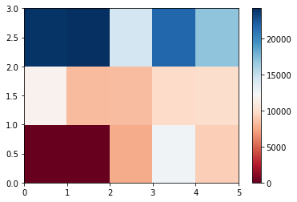

```python
#visualisasi heatmap
plt.pcolor(grouped_pivot, cmap='RdBu')
plt.colorbar()
plt.show()
```

Heatmap memplot variabel target (harga) dengan variabel 'roda penggerak' dan ‘body-style’ disumbu vertikal dan horizontal. Hal ini memungkinkan kita untuk memvisualisasikan bagaimana harga terkait dengan 'drive-wheel' dan 'body-style'. Label default belum menyampaikan informasi yang cukup kepada kita. Mari kita ubah label pada heatmap tersebut agar bisa memiliki informasi legend :

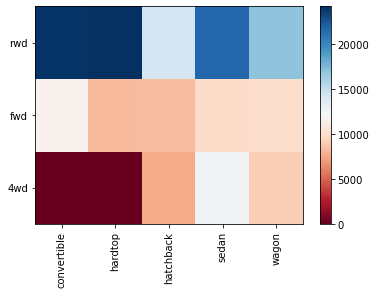

```python
fig, ax = plt.subplots()
im = ax.pcolor(grouped_pivot, cmap='RdBu')

# nama label
row_labels = grouped_pivot.columns.levels[1]
col_labels = grouped_pivot.index

# pindahkan ticks and labels ke tenah
ax.set_xticks(np.arange(grouped_pivot.shape[1]) + 0.5, minor=False)
ax.set_yticks(np.arange(grouped_pivot.shape[0]) + 0.5, minor=False)

# masukan  labels
ax.set_xticklabels(row_labels, minor=False)
ax.set_yticklabels(col_labels, minor=False)

# rotasi label
plt.xticks(rotation=90)

fig.colorbar(im)
plt.show()
```

## ANOVA: Analysis of Variance

**Analysis of Varians (ANOVA)** adalah metode statistik yang digunakan untuk menguji apakah ada perbedaan yang signifikan antara rata-rata dua kelompok atau lebih. ANOVA mengembalikan dua parameter F-Score: ANOVA mengasumsikan rata-rata semua kelompok adalah sama, anova akan menghitung seberapa jauh rata-rata yang sebenarnya menyimpang dari asumsi, dan melaporkannya sebagai F-Skore. Skor yang lebih besar berarti ada perbedaan yang lebih besar antara rata-rata. P-Value: Nilai-P menunjukkan seberapa signifikan secara statistik nilai skor yang dihitung.

ANOVA menganalisis perbedaan antara kelompok yang berbeda dari variabel yang sama, fungsi groupby akan berguna dalam kasus ANOVA. Mari kita lihat apakah jenis 'roda penggerak' mempengaruhi 'harga',

```python
# mengelompokan data 'drive-wheels' & 'price' berdasarkan 'drive-wheels'
grouped_test2=df_gptest[['drive-wheels', 'price']].groupby(['drive-wheels'])
grouped_test2.head(2)
```

|  | drive-wheels | price |
| --- | --- | --- |
| 0 | rwd | 13495.0 |
| 1 | rwd | 16500.0 |
| 3 | fwd | 13950.0 |
| 4 | 4wd | 17450.0 |
| 5 | fwd | 15250.0 |
| 136 | 4wd | 7603.0 |

```python
# tampilkan data
df_gptest
```

|  | drive-wheels | body-style | price |
| --- | --- | --- | --- |
| 0 | rwd | convertible | 13495.0 |
| 1 | rwd | convertible | 16500.0 |
| 2 | rwd | hatchback | 16500.0 |
| 3 | fwd | sedan | 13950.0 |
| 4 | 4wd | sedan | 17450.0 |
| ... | ... | ... | ... |
| 196 | rwd | sedan | 16845.0 |
| 197 | rwd | sedan | 19045.0 |
| 198 | rwd | sedan | 21485.0 |
| 199 | rwd | sedan | 22470.0 |
| 200 | rwd | sedan | 22625.0 |

201 rows × 3 columns

kita dapat menggunakan fungsi `'f_oneway'` di modul 'stats' untuk mendapatkan F-Score dan P-Value

```python
# ANOVA
f_val, p_val = stats.f_oneway(grouped_test2.get_group('fwd')['price'], grouped_test2.get_group('rwd')['price'], grouped_test2.get_group('4wd')['price'])

print( "ANOVA results: F=", f_val, ", P =", p_val)
```

```
ANOVA results: F= 67.95406500780399 , P = 3.3945443577151245e-23
```

Hasil ANOVA ini termasuk hasil yang bagus, dengan F-Score yang besar menunjukkan korelasi yang kuat dan nilai P hampir 0 menyiratkan signifikansi statistik yang hampir pasti. Tetapi apakah ini berarti ketiga kelompok yang diuji semuanya berkorelasi tinggi?

#### Separately: fwd and rwd

```python
# menampilkan f-score dan p-value'
f_val, p_val = stats.f_oneway(grouped_test2.get_group('fwd')['price'], grouped_test2.get_group('rwd')['price'])

print( "ANOVA results: F=", f_val, ", P =", p_val )
```

```
ANOVA results: F= 130.5533160959111 , P = 2.2355306355677845e-23
```

4wd and fwd

```python
# menampilkan f-score dan p-value
f_val, p_val = stats.f_oneway(grouped_test2.get_group('4wd')['price'], grouped_test2.get_group('fwd')['price'])

print("ANOVA results: F=", f_val, ", P =", p_val)
```

```
ANOVA results: F= 0.665465750252303 , P = 0.41620116697845666
```